# 07_Class_Diagrams

## Діаграми класів.

**Діаграма класів (Class diagram)** описує структуру системи, показуючи класи системи, їх атрибути, операції (або методи) та відносини між класами. Зображує статичне уявлення програми. Представляє типи об’єктів, що у системі, і відносини з-поміж них.

**Клас складається зі** своїх об’єктів, а також може успадковуватись від інших класів.

**Діаграма класів використовується** для візуалізації, опису, документування різних аспектів системи, а також для створення програмного коду, що виконується. Діаграма класів UML складається із набору класів та відносин між ними.

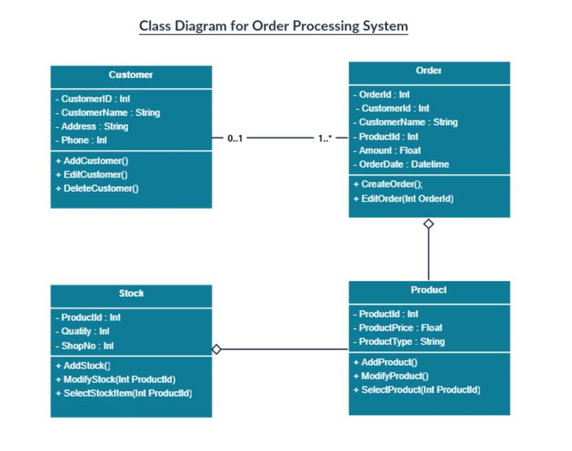

**Клас – опис групи об’єктів** з однаковими ролями у системі, що складається з:

- Структурні ознаки (атрибути).
- Поведінкові ознаки (операції).

**Структурні ознаки** (атрибути) визначають, що знають об’єкти класу:

- Стан об’єкта класу.
- Описи структурних чи статичних особливостей класу.

**Поведінкові ознаки** (операції) визначають, що можуть робити об’єкти класу:

- Метод взаємодії об’єктів.
- Операції (описи поведінкових чи динамічних характеристик класу).

**Позначення класу:**

- Назва/Ім’я класу.
- Атрибути класу.
- Операції класу (методи).

Ім’я класу відображається у першому розділі.

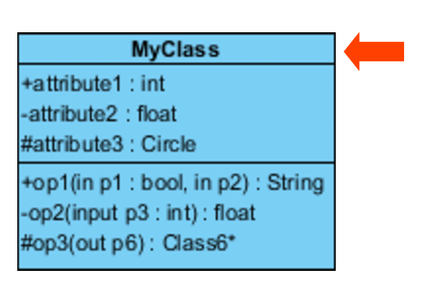

Атрибути показані у другому розділі. Тип атрибута відображається після двокрапки. Атрибути зіставляються із змінними-членами (елементами даних) у коді.

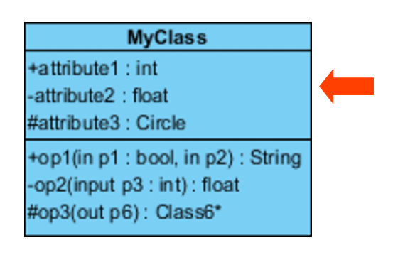

Операції класу (методи) показано у третьому розділі. Це послуги, які надаються класом. Тип значення методу, що повертається, відображається після двокрапки в кінці сигнатури методу. Тип параметрів методу, що повертається, відображається після двокрапки після імені параметра. Операції порівнюються з методами класу в коді.

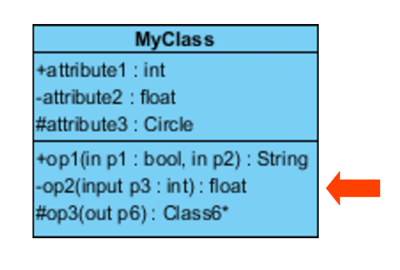

Клас `MyClass` має 3 атрибути та 3 операції. Параметр `p3` операції `op2` має тип `int`. Операція `op2` повертає число з плаваючою комою. Операція `op3` повертає покажчик (позначений `*`) на `Class6`.

**Клас може бути залучений до одного чи кілька відносин із іншими класами.** Зв’язок може бути одного з таких типів:

- Успадкування (або узагальнення).
- Асоціація.
- Агрегація.
- Композиція.
- Залежність.

**Успадкування (або узагальнення)** представляє відношення IS-A. `SubClass1` та `SubClass2` є спеціалізаціями `SuperClass`. Суцільна лінія з порожнистою стрілкою, що вказує від дочірнього до батьківського класу.

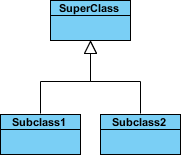

**Символи перед ім’ям атрибута та операції в класі позначають видимість** атрибута та операції:

`+` public

`-` private

`#` protected

`~` package

**Скільки об’єктів кожного класу беруть участь у відносинах (множинність)** можна виразити як:

`1` - рівно один.

`0..1` - нуль чи одиниця.

`0..*` або `*` - багато.

`1..*` - один чи кілька.

`3..4` або `6`, наприклад, - точний номер.

складні відносини – наприклад, `0..1` або `3..4` або `6.*` - означатимуть будь-яку кількість об’єктів, крім `2` або `5`.